# Stage 3d: the labour block on the regional core

The rollout stage 3c said could not happen — and what a bloc changes about what a column of `k` buys

## 1. What this is, and why it exists

`reports/stage3c_rollout.qmd` set out to roll the stage-3 blocks across the euro area and concluded it could not be done:

> Data availability is not the constraint. […] The constraint is the degrees-of-freedom budget, and it binds by roughly a factor of two: the system is already at `df = 8` with **one** country carrying the blocks, and a second fully-loaded country would need `k = 104` against `T = 98`.

**That conclusion was right about the eleven-country partition and does not bind on the six-entity one.** Stage 2d re-partitions the world — `de`, `fr`, `it`, `us`, `cn` and the `reu` bloc — and in doing so drops `k` from 76 to 46. The labour block still costs seven columns per entity; it is simply being added to a system with thirty columns of room instead of none.

**But the arithmetic is not the interesting part. What a bloc changes is what a column buys.** `reu` is one entity covering seven economies, so giving it the block extends the wage–price channel to seven countries for the price of one:

| Configuration | Labour entities | Economies covered | k | T | df | Feasible (df >= 4) |
| --- | --- | --- | --- | --- | --- | --- |
| stage 2d (no labour block) | 0 | 0 | 46 | 78 | 32 | yes |
| de | 1 | 1 | 53 | 78 | 25 | yes |
| de + reu | 2 | 8 | 60 | 78 | 18 | yes |
| de + reu + fr | 3 | 9 | 67 | 78 | 11 | yes |
| de + reu + fr + it | 4 | 10 | 74 | 78 | 4 | yes |

This report estimates the **de + reu** configuration: **8 of the eleven** modelled economies carry a wage–price block, at `df = 18`, against stage 3a’s **one** economy at `df = 15`.

| System | Economies with the block | Equations | k | T | df |
| --- | --- | --- | --- | --- | --- |
| Stage 2d (core) | 0 | 38 + 25 | 46 | 78 | 32 |
| Stage 3a (DE on stage 2b) | 1 | 74 + 39 | 83 | 98 | 15 |
| **Stage 3d (DE + REU on stage 2d)** | 8 | 50 + 33 | 60 | 78 | 18 |

Phase A only: `<iso2>_foreign_prices` stays exogenous. Stage 3a’s phase B — giving every partner an export-price equation so foreign prices become an identity — cost ten columns on eleven countries and would cost five here, but it is a separate question from the one this stage asks.

## 2. The bloc’s labour variables

`reu_wages` is the GDP-weighted average of seven national wage **growth** rates, not a euro-per-worker level, and `reu_employment` is an index rather than a headcount. That is the right object for a model estimated in growth space — every stage-3a identity is a statement about growth rates, and they reproduce on the bloc exactly as on a country — but the levels are not quotable.

HICP basket split. A bloc has no published basket, so bloc_hicp_weights() averages its members’ with the same weights the bloc’s series were built from; the members are shown indented.

| entity | nonenergy | energy |
| --- | --- | --- |
| DE | 0.8875 | 0.1125 |
| REU | 0.9006 | 0.0994 |
| AT | 0.9159 | 0.0841 |
| BE | 0.8939 | 0.1061 |
| ES | 0.8918 | 0.1082 |
| GR | 0.9173 | 0.0827 |
| IE | 0.9054 | 0.0946 |
| NL | 0.9019 | 0.0981 |
| PT | 0.9101 | 0.0899 |

The bloc’s energy share (9.9%) sits inside its members’ range and just below Germany’s (11.3%). The weights are renormalised to sum to exactly 1, which `labour_block()` requires: the split *partitions* the basket, and seven rounded weights can otherwise leave a 1e-4 residual that would abort the block for no real reason.

### The foreign-price index is better here than in stage 3a

foreign_price_weights(): the trade-weighted index each entity’s export and import prices load on.

| Entity | Partner weights (renormalised) | row_gdp weight dropped |
| --- | --- | --- |
| DE | fr 0.119, it 0.096, us 0.180, cn 0.191, reu 0.414 | 0.456 |
| REU | de 0.315, fr 0.175, it 0.114, us 0.210, cn 0.186 | 0.458 |

## 3. Does it estimate?

stage2_preflight(): all nine checks pass.

| check | ok | detail |
| --- | --- | --- |
| identity RHS variables all resolve | TRUE | - |
| no variable defined twice | TRUE | - |
| every variable has a panel series | TRUE | 92 variables present |
| no internal NAs in required series | TRUE | - |
| identities declared last | TRUE | 50 stochastic then 33 identities |
| no lagged endogenous name prefixes another | TRUE | - |
| system identified | TRUE | 10/10 seeds pass order + rank |
| k < T (x’x invertible, Wishart df > 0) | TRUE | k = 60, T = 78, df = 18 |
| exact identities hold in the panel | TRUE | 21 checked, worst \|error\| 9.59e-14 |

tune_tau_system(): equations outside the 20-60% acceptance band, by round.

| iteration | flagged |
| --- | --- |
| 0 | 15 |
| 1 | 3 |
| 2 | 2 |
| 3 | 0 |

`tune_tau_system()` converges to **zero** flagged equations — which stage 3a also managed, but at `df = 15` rather than 18. Acceptance rates run 29.4%–43.5%.

**46 of 50 equations have a Metropolis step.** The 4 that do not are exactly the ones with no contemporaneous endogenous regressor, and they are the expected ones:

Equations with no Metropolis step – energy prices (oil and FX only) and import prices (whose only non-exogenous regressor, foreign_prices, is exogenous under phase A). Documented behaviour, not a failure.

| equation |
| --- |
| de_energy_prices |
| de_import_prices |
| reu_energy_prices |
| reu_import_prices |

The six most persistent own lags. None is flagged.

| equation | term | estimate | ci_high | flagged |
| --- | --- | --- | --- | --- |
| reu_unemployment | reu_unemployment.L(1) | 0.996 | 1.052 | FALSE |
| us_policy_rate | us_policy_rate.L(1) | 0.986 | 1.084 | FALSE |
| ea_policy_rate | ea_policy_rate.L(1) | 0.974 | 1.051 | FALSE |
| reu_spread | reu_spread.L(1) | 0.968 | 1.078 | FALSE |
| de_unemployment | de_unemployment.L(1) | 0.959 | 0.984 | FALSE |
| us_spread | us_spread.L(1) | 0.956 | 1.117 | FALSE |

**No own lag is explosive**, which is the check stage 3b failed: at `df = 8` `de_long_rate` crossed to 1.004 the moment debt became its fifth regressor. At `df = 18` the most persistent equation here is reu_unemployment at 0.996.

identity_consistency(). The exact identities hold to 9.6e-14; the ones reported but never flagged are the GDP and domestic-demand identities.

| identity | space | max_abs_error | exact_expected | ok |
| --- | --- | --- | --- | --- |
| reu_gdp | rate | 5.0027 | FALSE | TRUE |
| reu_domestic_demand | rate | 3.5805 | FALSE | TRUE |
| it_domestic_demand | rate | 2.9630 | FALSE | TRUE |
| de_domestic_demand | rate | 2.3233 | FALSE | TRUE |
| us_domestic_demand | rate | 2.2420 | FALSE | TRUE |
| de_gdp | rate | 1.9607 | FALSE | TRUE |
| it_gdp | rate | 1.9200 | FALSE | TRUE |
| fr_gdp | rate | 1.6589 | FALSE | TRUE |

**NoteA bug this stage exposed**

`reu_prices` initially failed the exact-identity check by **1.47e-07** — small, but the identity is supposed to be exact. The cause was in `identity_equation()`, which rendered weights with `format()`’s default **7 significant digits** while the identity’s left-hand side series is built from the full-precision numeric weight. Every weight in the project until now was a rounded expenditure or trade share, so the two always agreed; the bloc’s HICP split is a seven-member average and is not a round number. koma has no identity-consistency check, so this would have been enforced in silence. Fixed by rendering 15 digits, which leaves every already-rounded weight identical — verified against the cached stage-2b and 2c systems.

## 4. What the bloc identifies that Germany alone does not

| Equation | Entity | Term | Estimate | 90% interval |
| --- | --- | --- | --- | --- |
| Wage Phillips curve | DE (stage 3a) | de_unemployment | -0.136 | [-0.327, 0.038] |
|  | DE / REU (stage 3d) | de_unemployment / reu_unemployment | -0.105 / -0.176 | [-0.278, 0.057] / [-0.301, -0.053] |
| Okun (employment) | DE | de_gdp | 0.101 | [0.060, 0.154] |
|  | REU | reu_gdp | 0.349 | [0.288, 0.400] |
| Export-price pass-through | DE | de_foreign_prices | 0.464 | [0.256, 0.662] |
|  | REU | reu_foreign_prices | 0.909 | [0.561, 1.250] |

**The wage Phillips curve is identified on the bloc and not on Germany.** Germany’s wage–unemployment coefficient is -0.105 with an interval of [-0.278, 0.057] — correctly signed but straddling zero, which is also what stage 3a found on its own window. The bloc’s is -0.176, interval [-0.301, -0.053] — **the interval excludes zero.**

That is the aggregation working *for* identification rather than against it, and it is worth being precise about why. Germany’s unemployment rate moves in a narrow band over this window; the bloc’s is a GDP-weighted average that includes Spain, Greece and Ireland, whose unemployment rates swung by tens of percentage points across the sovereign-debt crisis. The bloc has far more variation in the regressor, and a wage equation can see the relationship through it. `reu_employment`’s Okun coefficient (0.349 against Germany’s 0.101) says the same thing from the other side: employment in the bloc is far more responsive to output than in Germany, which matches everything known about those labour markets.

**This cuts the other way too, and the sign checks say where.**

sign_checks() across all six entities: 56 of 62 pass.

|  | fail | pass |
| --- | --- | --- |
| absorption_positive | 0 | 1 |
| consumption_loads_on_real_income | 0 | 2 |
| consumption_rate_channel_negative | 3 | 2 |
| demand_rate_channel_negative | 0 | 1 |
| energy_prices_fall_on_euro_appreciation | 0 | 2 |
| energy_prices_load_on_oil | 0 | 2 |
| export_prices_load_on_foreign_prices | 0 | 2 |
| export_prices_load_on_ulc | 1 | 1 |
| exports_fall_in_own_price | 0 | 2 |
| exports_rise_in_competitor_price | 0 | 2 |
| import_elasticity_positive | 0 | 6 |
| import_price_passthrough_positive | 0 | 2 |
| import_prices_fall_on_euro_appreciation | 0 | 2 |
| import_prices_load_on_foreign_prices | 0 | 2 |
| import_prices_load_on_oil | 0 | 2 |
| mpc_in_0_1 | 0 | 5 |
| okun_employment_positive | 0 | 2 |
| okun_unemployment_negative | 0 | 2 |
| phillips_curve_positive | 0 | 4 |
| price_phillips_curve_negative | 0 | 2 |
| spread_loads_on_prices_positive | 1 | 5 |
| ulc_passthrough_positive | 0 | 2 |
| wage_phillips_curve_negative | 0 | 2 |
| wage_price_indexation_in_0_1 | 1 | 1 |

The failures.

| iso2 | check | term | estimate |
| --- | --- | --- | --- |
| fr | consumption_rate_channel_negative | fr_long_rate | 0.0112 |
| fr | spread_loads_on_prices_positive | fr_prices | -0.0411 |
| it | consumption_rate_channel_negative | it_long_rate | 0.0110 |
| reu | consumption_rate_channel_negative | reu_long_rate | 0.0029 |
| reu | wage_price_indexation_in_0_1 | reu_prices | -0.0665 |
| reu | export_prices_load_on_ulc | reu_ulc | -0.0762 |

Two of the 6 are in the bloc’s own labour block and both are about **pass-through**, not about the cycle: `reu_wages` does not index to `reu_prices` (-0.067) and `reu_export_prices` does not load on `reu_ulc` (-0.076). Both are plausibly the aggregation: indexation arrangements and cost pass-through differ sharply across seven economies, so averaging their growth rates averages away the very mechanism the coefficient is trying to measure. The cyclical relationships — which depend on *co-movement* rather than on a shared institutional parameter — survive aggregation; the institutional ones do not.

That is a genuine limitation of the bloc, and it is the opposite trade to the one Germany makes: Germany has the institutions but not the variation.

**NoteA second bug this stage exposed**

`sign_checks()` reported `phillips_curve_positive` as a failure for both labour entities with `estimate = NA`. Under the labour block `<iso2>_prices` is an **identity** over the energy and non-energy sub-indices, so there is no `prices ~ gdp` coefficient to look at — the same claim is made and checked by `price_phillips_curve_negative` on `nonenergy_prices`. The stage-2c rule is now dropped for a labour country, exactly as the `spread` and `financial` rules already were. Two deliberate absences were being reported as failures.

## 5. Structure

contemporaneous_reachability() from each policy rate.

| policy rate | endogenous reached | price variables reached |
| --- | --- | --- |
| ea_policy_rate | 79 / 83 | 11 |
| us_policy_rate | 79 / 83 | 11 |
| cn_policy_rate | 79 / 83 | 11 |

All three policy rates reach every price variable in the system, including the disaggregated ones the labour block introduces. Stage 2c’s structural fix survives both the re-partition and the block.

## 6. Eight-quarter forecast

8 quarters from **2025Q1** to **2026Q4**, 1000 posterior draws. Actuals exist for the first 5 quarters; the rest is genuinely ahead of the data.

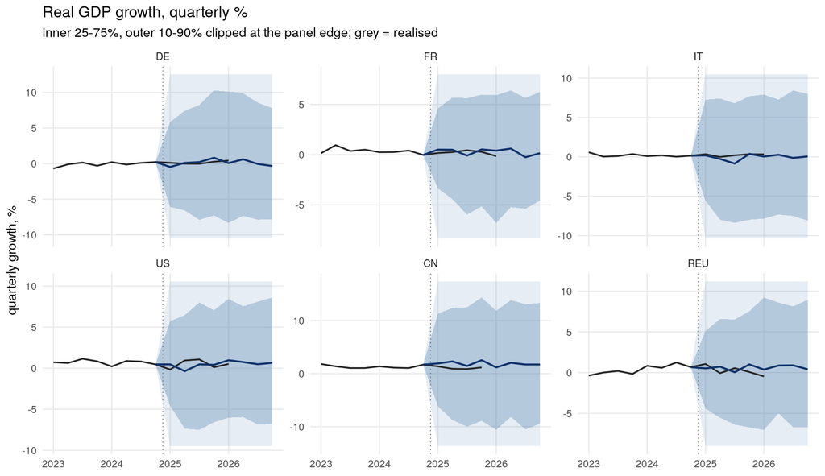

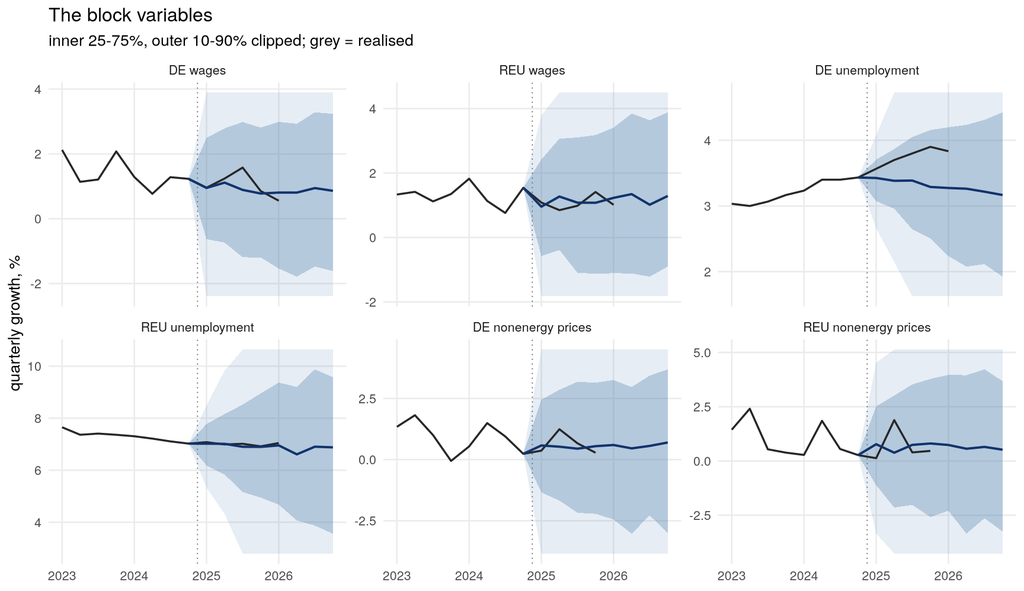

Share of draws discarded as explosive. Compare stage 2d (GDP 0.40 at h8, df 32) and stage 3a (0.70, df 15): this system sits between them, where df 18 says it should.

| Concept | explosive share h1 | h8 |
| --- | --- | --- |
| gdp | 0.0514 | 0.5454 |
| prices | 0.0063 | 0.4247 |
| wages | 0.0020 | 0.3585 |
| unemployment | 0.0010 | 0.3700 |

How each exogenous series was carried to the horizon.

| variable | method | periods_added |
| --- | --- | --- |
| covid_2020q1 | zero (dummy) | 3 |
| covid_2020q2 | zero (dummy) | 3 |
| covid_2020q3 | zero (dummy) | 3 |
| covid_2021q2 | zero (dummy) | 3 |
| de_foreign_prices | trailing-4Q avg growth (0.00%/q) | 8 |
| eur_usd | trailing-4Q avg growth (2.67%/q) | 3 |
| oil_price | trailing-4Q avg growth (1.41%/q) | 3 |
| reu_foreign_prices | trailing-4Q avg growth (0.00%/q) | 8 |
| row_gdp | trailing-4Q avg growth (0.44%/q) | 3 |

**One caveat the extension table makes visible.** `de_foreign_prices` and `reu_foreign_prices` are extended by **eight** quarters, not three — the whole forecast window — because they are chained indices over partners’ export prices and stop where the shortest partner does, which is China’s IFS export-price index at 2024Q4. Their extrapolated path is flat (trailing-4Q average growth of 0.00%/q, export prices having been flat), so this is a conservative assumption rather than a wild one, but the price channel’s external driver is assumption rather than data across the whole horizon.

## 7. Verdict

| Economies with a wage–price channel | **8 of 11**, against stage 3a’s 1 |
| --- | --- |
| `df` | **18**, against stage 3a’s 15 and stage 3b’s 8 |
| Acceptance tuning | converges to **0** flagged equations |
| Explosive own lags | **none** |
| Sign checks | 56 of 62 |
| Wage Phillips curve | **identified on the bloc**, not on Germany |
| Wage indexation, ULC pass-through | **lost** to aggregation on the bloc |

**Stage 3c’s finding was not wrong; it was partition-specific.** “The rollout cannot happen” was a true statement about eleven countries and a false one about the world. What changed is not the estimator, the data or the block — it is that a bloc makes one column of `k` buy seven economies instead of one.

**What this does not do.** It does not give Spain or Greece their own wage equation — they have a share in one. An institution-specific question (national indexation, a country’s own ULC pass-through) still needs a country-level block, and stage 3c’s arithmetic still applies to that. The bloc answers *regional* questions: what a euro-area-wide wage–price spiral does to the core, and how the labour channel changes a spillover.